# Analysis of antibody titers from a bunch of donors

## Table of contents

- Data
- **Antibody titer vs. age**

  Linear regression

  Smoothing
- Prediction
- Test H2 vaccinated vs. non vaccinated

## Data

Data were loaded from several csv files (one per strain) and merged into two dataframes, one for IC50 values and one for the EC50 values.

## Data cleaning

IC_50 could not be computed for H5 and H7. For these two strains, rather than the inhibitory concentrations, the inhibition value at the first dilution is reported, expressed in percentage.

EC50 data present two outliers (one in H2 and one in H4 titers): their value for effective concentration was lower than -40 (in log scale) and for this reason were removed.

```r
ec_data$H2_log[ec_data$H2_log < -40] <- NA
ec_data$H4_log[ec_data$H4_log < -40] <- NA
```

The following plots show the distribution of values, one boxplot per strain. IC50 for H5 and H7 are shown separately because the scale is different (percentage).

#### IC50

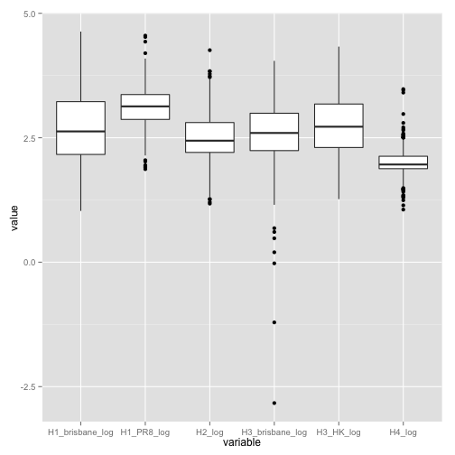

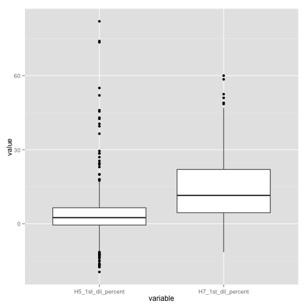

#### EC50

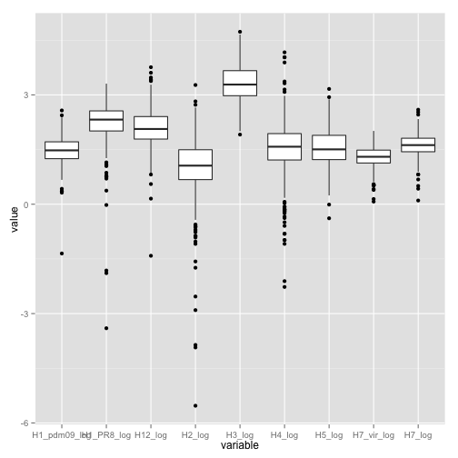

### Merge with donors data

Donors data were taken from the file `donors_view.csv` in the `data/` directory. We excluded donors enrolled in the Novartis study, HIV positive and those for which the number of vaccinations is not defined.

We are left with 271 donors, 141 females and 130 males, for which we can plot the following characteristics.

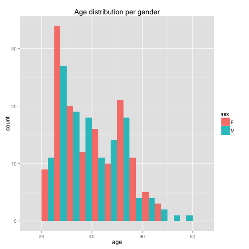

[output not shown]

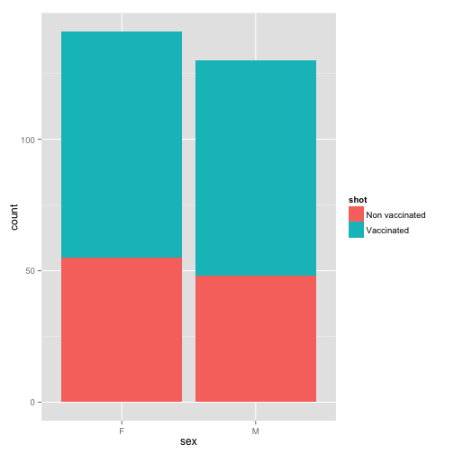

```
##
##                   F  M
##   Non vaccinated 55 48
##   Vaccinated     86 82
```

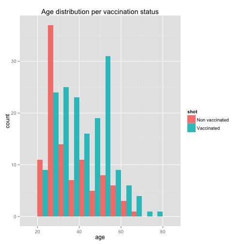

It is important to point out that the groups are not homogeneous, vaccinated are older than non vaccinated, as seen in the plot below.

[output not shown]

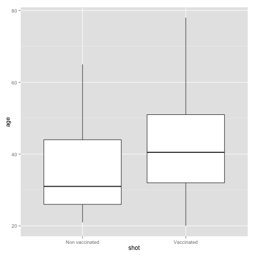

We show the boxplots again, limited to donors considered here.

#### IC50

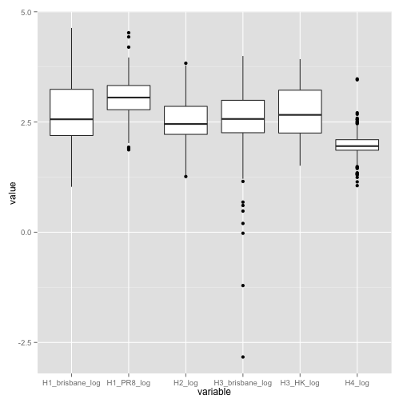

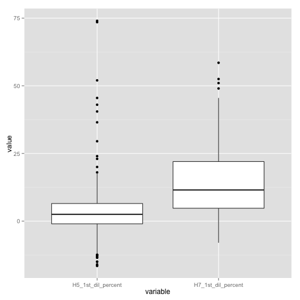

H3 Brisbane has a few outliers: we remove those below zero.

```r
ic_data$H3_brisbane_log[ic_data$H3_brisbane_log < 0] <- NA
```

#### EC50

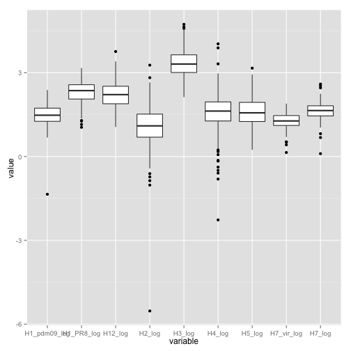

We observe a few strain with outliers: H1 pandemic 2009, H2 and H4. We remove the lowest observation on each strain.

```r
ec_data$H1_pdm09_log[ec_data$H1_pdm09_log < 0] <- NA
ec_data$H2_log[ec_data$H2_log < -3] <- NA
ec_data$H4_log[ec_data$H4_log < -1.5] <- NA
```

### IC50

[output not shown]

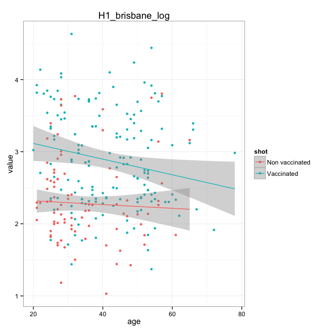

```
## [1] "Fit on the non vaccinated"
##
## Call:
## glm(formula = value ~ age, data = melted, subset = (shot == "Non vaccinated"))
##
## Deviance Residuals:
##     Min       1Q   Median       3Q      Max
## -1.0395  -0.1996  -0.0142   0.3123   0.7417
##
## Coefficients:
##             Estimate Std. Error t value Pr(>|t|)
## (Intercept)  2.85961    0.12925   22.12   <2e-16 ***
## age          0.00183    0.00350    0.52      0.6
## ---
## Signif. codes:  0 '***' 0.001 '**' 0.01 '*' 0.05 '.' 0.1 ' ' 1
##
## (Dispersion parameter for gaussian family taken to be 0.1454)
##
##     Null deviance: 13.273  on 92  degrees of freedom
## Residual deviance: 13.234  on 91  degrees of freedom
##   (10 observations deleted due to missingness)
## AIC: 88.59
##
## Number of Fisher Scoring iterations: 2
##
## [1] "Fit on the vaccinated"
##
## Call:
## glm(formula = value ~ age, data = melted, subset = (shot == "Vaccinated"))
##
## Deviance Residuals:
##     Min       1Q   Median       3Q      Max
## -1.1665  -0.3214  -0.0143   0.2311   1.4356
##
## Coefficients:
##             Estimate Std. Error t value Pr(>|t|)
## (Intercept)  2.87275    0.11927   24.09   <2e-16 ***
## age          0.00636    0.00275    2.31    0.022 *
## ---
## Signif. codes:  0 '***' 0.001 '**' 0.01 '*' 0.05 '.' 0.1 ' ' 1
##
## (Dispersion parameter for gaussian family taken to be 0.1809)
##
##     Null deviance: 30.264  on 163  degrees of freedom
## Residual deviance: 29.300  on 162  degrees of freedom
##   (4 observations deleted due to missingness)
## AIC: 189
##
## Number of Fisher Scoring iterations: 2
```

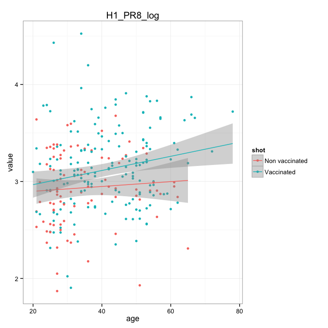

```
## [1] "Fit on the non vaccinated"
##
## Call:
## glm(formula = value ~ age, data = melted, subset = (shot == "Non vaccinated"))
##
## Deviance Residuals:
##     Min       1Q   Median       3Q      Max
## -0.9166  -0.1728  -0.0104   0.1740   0.8543
##
## Coefficients:
##             Estimate Std. Error t value Pr(>|t|)
## (Intercept)  1.83350    0.09479   19.34  < 2e-16 ***
## age          0.01905    0.00254    7.51  2.7e-11 ***
## ---
## Signif. codes:  0 '***' 0.001 '**' 0.01 '*' 0.05 '.' 0.1 ' ' 1
##
## (Dispersion parameter for gaussian family taken to be 0.08503)
##
##     Null deviance: 13.1304  on 99  degrees of freedom
## Residual deviance:  8.3325  on 98  degrees of freedom
##   (3 observations deleted due to missingness)
## AIC: 41.29
##
## Number of Fisher Scoring iterations: 2
##
## [1] "Fit on the vaccinated"
##
## Call:
## glm(formula = value ~ age, data = melted, subset = (shot == "Vaccinated"))
##
## Deviance Residuals:
##     Min       1Q   Median       3Q      Max
## -1.2207  -0.2494   0.0004   0.2249   0.9413
##
## Coefficients:
##             Estimate Std. Error t value Pr(>|t|)
## (Intercept)  1.28363    0.11523    11.1   <2e-16 ***
## age          0.03092    0.00265    11.7   <2e-16 ***
## ---
## Signif. codes:  0 '***' 0.001 '**' 0.01 '*' 0.05 '.' 0.1 ' ' 1
##
## (Dispersion parameter for gaussian family taken to be 0.1694)
##
##     Null deviance: 50.389  on 162  degrees of freedom
## Residual deviance: 27.274  on 161  degrees of freedom
##   (5 observations deleted due to missingness)
## AIC: 177.2
##
## Number of Fisher Scoring iterations: 2
```

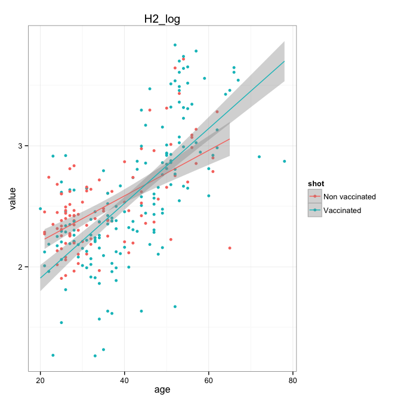

```
## [1] "Fit on the non vaccinated"
##
## Call:
## glm(formula = value ~ age, data = melted, subset = (shot == "Non vaccinated"))
##
## Deviance Residuals:
##     Min       1Q   Median       3Q      Max
## -2.3104  -0.3688  -0.0187   0.4030   1.5889
##
## Coefficients:
##             Estimate Std. Error t value Pr(>|t|)
## (Intercept)  2.62674    0.22556   11.65   <2e-16 ***
## age         -0.00433    0.00608   -0.71     0.48
## ---
## Signif. codes:  0 '***' 0.001 '**' 0.01 '*' 0.05 '.' 0.1 ' ' 1
##
## (Dispersion parameter for gaussian family taken to be 0.461)
##
##     Null deviance: 41.722  on 91  degrees of freedom
## Residual deviance: 41.488  on 90  degrees of freedom
##   (11 observations deleted due to missingness)
## AIC: 193.8
##
## Number of Fisher Scoring iterations: 2
##
## [1] "Fit on the vaccinated"
##
## Call:
## glm(formula = value ~ age, data = melted, subset = (shot == "Vaccinated"))
##
## Deviance Residuals:
##     Min       1Q   Median       3Q      Max
## -2.1581  -0.3812   0.0065   0.3704   1.2938
##
## Coefficients:
##             Estimate Std. Error t value Pr(>|t|)
## (Intercept)  2.61662    0.16756   15.62   <2e-16 ***
## age          0.00239    0.00390    0.61     0.54
## ---
## Signif. codes:  0 '***' 0.001 '**' 0.01 '*' 0.05 '.' 0.1 ' ' 1
##
## (Dispersion parameter for gaussian family taken to be 0.3494)
##
##     Null deviance: 54.638  on 157  degrees of freedom
## Residual deviance: 54.506  on 156  degrees of freedom
##   (10 observations deleted due to missingness)
## AIC: 286.2
##
## Number of Fisher Scoring iterations: 2
```

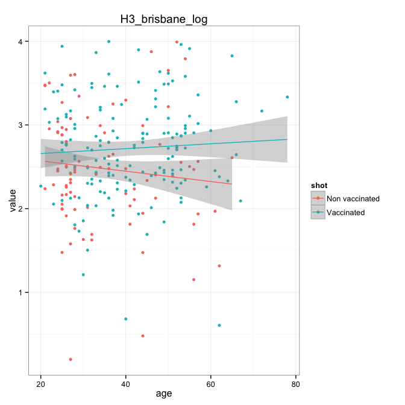

```
## [1] "Fit on the non vaccinated"
##
## Call:
## glm(formula = value ~ age, data = melted, subset = (shot == "Non vaccinated"))
##
## Deviance Residuals:
##     Min       1Q   Median       3Q      Max
## -1.0199  -0.2890  -0.0415   0.2066   0.9165
##
## Coefficients:
##             Estimate Std. Error t value Pr(>|t|)
## (Intercept)  1.64297    0.14286   11.50  < 2e-16 ***
## age          0.02747    0.00381    7.22  1.2e-10 ***
## ---
## Signif. codes:  0 '***' 0.001 '**' 0.01 '*' 0.05 '.' 0.1 ' ' 1
##
## (Dispersion parameter for gaussian family taken to be 0.1907)
##
##     Null deviance: 28.239  on 97  degrees of freedom
## Residual deviance: 18.308  on 96  degrees of freedom
##   (5 observations deleted due to missingness)
## AIC: 119.7
##
## Number of Fisher Scoring iterations: 2
##
## [1] "Fit on the vaccinated"
##
## Call:
## glm(formula = value ~ age, data = melted, subset = (shot == "Vaccinated"))
##
## Deviance Residuals:
##     Min       1Q   Median       3Q      Max
## -1.3714  -0.3451  -0.0295   0.3551   1.0860
##
## Coefficients:
##             Estimate Std. Error t value Pr(>|t|)
## (Intercept)  1.63454    0.13611   12.01  < 2e-16 ***
## age          0.02750    0.00313    8.78  2.2e-15 ***
## ---
## Signif. codes:  0 '***' 0.001 '**' 0.01 '*' 0.05 '.' 0.1 ' ' 1
##
## (Dispersion parameter for gaussian family taken to be 0.2386)
##
##     Null deviance: 57.06  on 163  degrees of freedom
## Residual deviance: 38.65  on 162  degrees of freedom
##   (4 observations deleted due to missingness)
## AIC: 234.4
##
## Number of Fisher Scoring iterations: 2
```

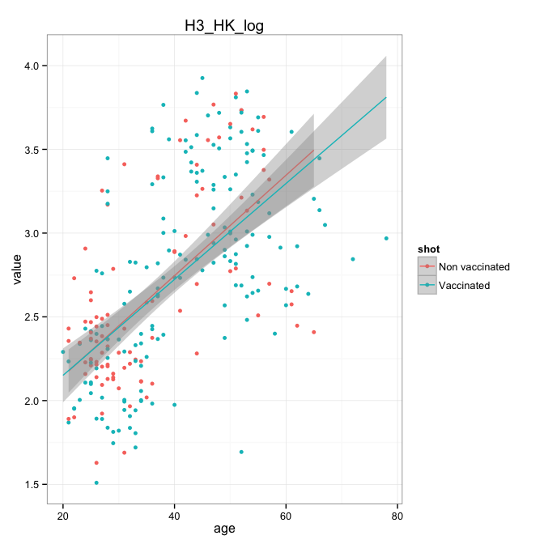

```
## [1] "Fit on the non vaccinated"
##
## Call:
## glm(formula = value ~ age, data = melted, subset = (shot == "Non vaccinated"))
##
## Deviance Residuals:
##     Min       1Q   Median       3Q      Max
## -0.9017  -0.0594   0.0143   0.1637   0.5863
##
## Coefficients:
##             Estimate Std. Error t value Pr(>|t|)
## (Intercept)  1.99637    0.08653   23.07   <2e-16 ***
## age         -0.00146    0.00229   -0.64     0.52
## ---
## Signif. codes:  0 '***' 0.001 '**' 0.01 '*' 0.05 '.' 0.1 ' ' 1
##
## (Dispersion parameter for gaussian family taken to be 0.06363)
##
##     Null deviance: 5.625  on 89  degrees of freedom
## Residual deviance: 5.599  on 88  degrees of freedom
##   (13 observations deleted due to missingness)
## AIC: 11.46
##
## Number of Fisher Scoring iterations: 2
##
## [1] "Fit on the vaccinated"
##
## Call:
## glm(formula = value ~ age, data = melted, subset = (shot == "Vaccinated"))
##
## Deviance Residuals:
##     Min       1Q   Median       3Q      Max
## -0.6798  -0.1293  -0.0283   0.1116   1.5030
##
## Coefficients:
##             Estimate Std. Error t value Pr(>|t|)
## (Intercept)  1.92830    0.08785    21.9   <2e-16 ***
## age          0.00121    0.00201     0.6     0.55
## ---
## Signif. codes:  0 '***' 0.001 '**' 0.01 '*' 0.05 '.' 0.1 ' ' 1
##
## (Dispersion parameter for gaussian family taken to be 0.09045)
##
##     Null deviance: 13.782  on 153  degrees of freedom
## Residual deviance: 13.749  on 152  degrees of freedom
##   (14 observations deleted due to missingness)
## AIC: 70.97
##
## Number of Fisher Scoring iterations: 2
```

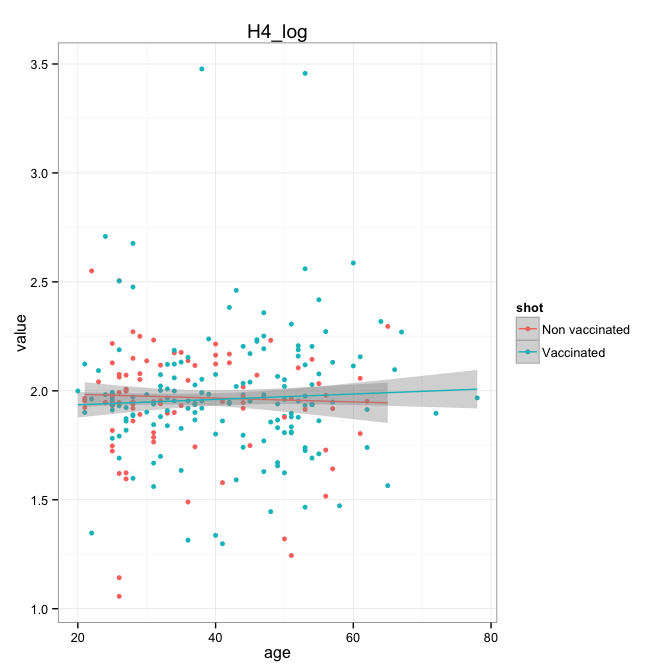

[output not shown]

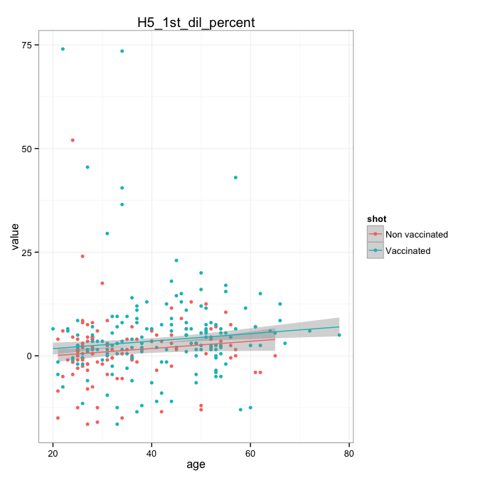

```
## [1] "Fit on the non vaccinated"
##
## Call:
## glm(formula = value ~ age, data = melted, subset = (shot == "Non vaccinated"))
##
## Deviance Residuals:
##    Min      1Q  Median      3Q     Max
## -20.77   -8.15   -2.11    7.28   29.83
##
## Coefficients:
##             Estimate Std. Error t value Pr(>|t|)
## (Intercept)  13.4257     3.6418    3.69  0.00037 ***
## age           0.0285     0.0982    0.29  0.77193
## ---
## Signif. codes:  0 '***' 0.001 '**' 0.01 '*' 0.05 '.' 0.1 ' ' 1
##
## (Dispersion parameter for gaussian family taken to be 131.1)
##
##     Null deviance: 13248  on 102  degrees of freedom
## Residual deviance: 13237  on 101  degrees of freedom
## AIC: 798.5
##
## Number of Fisher Scoring iterations: 2
##
## [1] "Fit on the vaccinated"
##
## Call:
## glm(formula = value ~ age, data = melted, subset = (shot == "Vaccinated"))
##
## Deviance Residuals:
##    Min      1Q  Median      3Q     Max
## -21.58   -9.83   -1.78    7.95   43.18
##
## Coefficients:
##             Estimate Std. Error t value Pr(>|t|)
## (Intercept)   6.6675     3.4462    1.93    0.055 .
## age           0.1730     0.0797    2.17    0.031 *
## ---
## Signif. codes:  0 '***' 0.001 '**' 0.01 '*' 0.05 '.' 0.1 ' ' 1
##
## (Dispersion parameter for gaussian family taken to be 156.2)
##
##     Null deviance: 26669  on 167  degrees of freedom
## Residual deviance: 25933  on 166  degrees of freedom
## AIC: 1329
##
## Number of Fisher Scoring iterations: 2
```

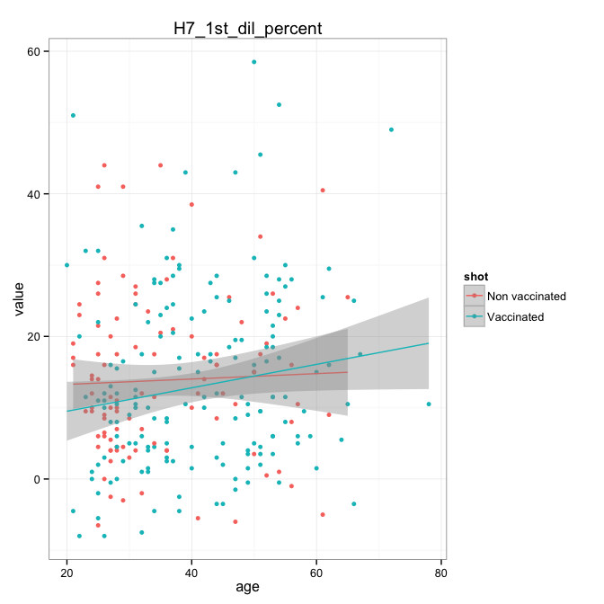

### EC50

```
## [1] "Fit on the non vaccinated"
##
## Call:
## glm(formula = value ~ age, data = melted, subset = (shot == "Non vaccinated"))
##
## Deviance Residuals:
##     Min       1Q   Median       3Q      Max
## -0.7154  -0.1894   0.0074   0.1568   0.7970
##
## Coefficients:
##             Estimate Std. Error t value Pr(>|t|)
## (Intercept)  1.30591    0.10733   12.17   <2e-16 ***
## age          0.00158    0.00289    0.55     0.59
## ---
## Signif. codes:  0 '***' 0.001 '**' 0.01 '*' 0.05 '.' 0.1 ' ' 1
##
## (Dispersion parameter for gaussian family taken to be 0.1119)
##
##     Null deviance: 11.223  on 101  degrees of freedom
## Residual deviance: 11.189  on 100  degrees of freedom
##   (1 observation deleted due to missingness)
## AIC: 70.04
##
## Number of Fisher Scoring iterations: 2
##
## [1] "Fit on the vaccinated"
##
## Call:
## glm(formula = value ~ age, data = melted, subset = (shot == "Vaccinated"))
##
## Deviance Residuals:
##     Min       1Q   Median       3Q      Max
## -0.6581  -0.2210  -0.0095   0.2005   0.7944
##
## Coefficients:
##             Estimate Std. Error t value Pr(>|t|)
## (Intercept)  1.30462    0.08280   15.76  < 2e-16 ***
## age          0.00643    0.00191    3.36  0.00097 ***
## ---
## Signif. codes:  0 '***' 0.001 '**' 0.01 '*' 0.05 '.' 0.1 ' ' 1
##
## (Dispersion parameter for gaussian family taken to be 0.09019)
##
##     Null deviance: 15.989  on 167  degrees of freedom
## Residual deviance: 14.971  on 166  degrees of freedom
## AIC: 76.56
##
## Number of Fisher Scoring iterations: 2
```

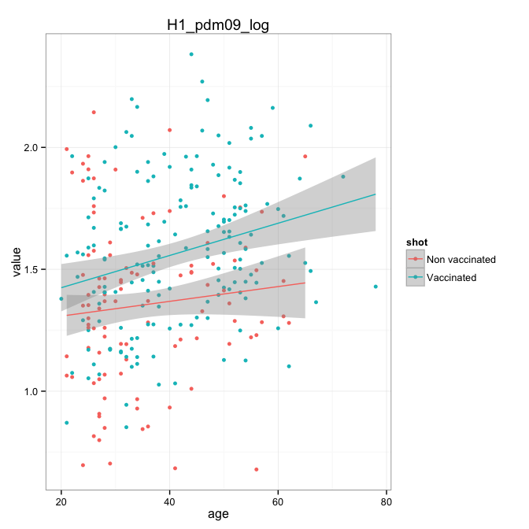

```
## [1] "Fit on the non vaccinated"
##
## Call:
## glm(formula = value ~ age, data = melted, subset = (shot == "Non vaccinated"))
##
## Deviance Residuals:
##     Min       1Q   Median       3Q      Max
## -0.9319  -0.2240   0.0315   0.2021   1.0795
##
## Coefficients:
##             Estimate Std. Error t value Pr(>|t|)
## (Intercept)  1.78146    0.11363   15.68   <2e-16 ***
## age          0.00854    0.00306    2.79   0.0064 **
## ---
## Signif. codes:  0 '***' 0.001 '**' 0.01 '*' 0.05 '.' 0.1 ' ' 1
##
## (Dispersion parameter for gaussian family taken to be 0.1276)
##
##     Null deviance: 13.878  on 102  degrees of freedom
## Residual deviance: 12.887  on 101  degrees of freedom
## AIC: 84.21
##
## Number of Fisher Scoring iterations: 2
##
## [1] "Fit on the vaccinated"
##
## Call:
## glm(formula = value ~ age, data = melted, subset = (shot == "Vaccinated"))
##
## Deviance Residuals:
##     Min       1Q   Median       3Q      Max
## -0.9077  -0.1988  -0.0012   0.1829   0.7736
##
## Coefficients:
##             Estimate Std. Error t value Pr(>|t|)
## (Intercept)  2.14164    0.08398   25.50   <2e-16 ***
## age          0.00785    0.00194    4.04    8e-05 ***
## ---
## Signif. codes:  0 '***' 0.001 '**' 0.01 '*' 0.05 '.' 0.1 ' ' 1
##
## (Dispersion parameter for gaussian family taken to be 0.09278)
##
##     Null deviance: 16.919  on 167  degrees of freedom
## Residual deviance: 15.402  on 166  degrees of freedom
## AIC: 81.33
##
## Number of Fisher Scoring iterations: 2
```

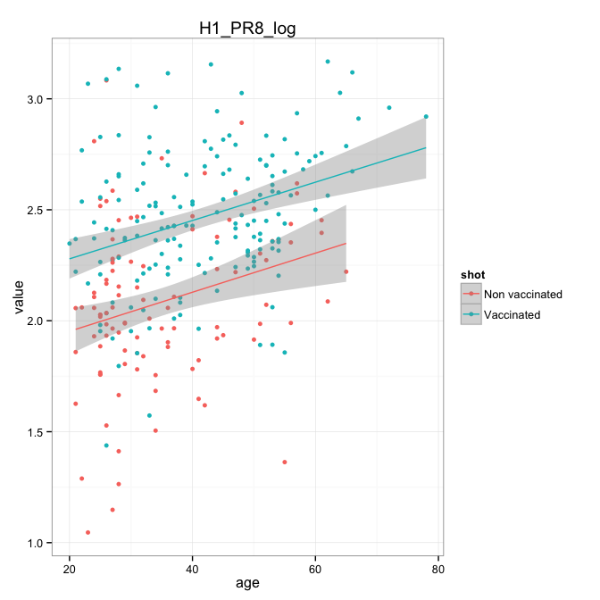

```
## [1] "Fit on the non vaccinated"
##
## Call:
## glm(formula = value ~ age, data = melted, subset = (shot == "Non vaccinated"))
##
## Deviance Residuals:
##     Min       1Q   Median       3Q      Max
## -1.0535  -0.2873  -0.0308   0.2394   1.1135
##
## Coefficients:
##             Estimate Std. Error t value Pr(>|t|)
## (Intercept)  2.50812    0.13227   18.96   <2e-16 ***
## age         -0.00933    0.00357   -2.62     0.01 *
## ---
## Signif. codes:  0 '***' 0.001 '**' 0.01 '*' 0.05 '.' 0.1 ' ' 1
##
## (Dispersion parameter for gaussian family taken to be 0.1729)
##
##     Null deviance: 18.644  on 102  degrees of freedom
## Residual deviance: 17.461  on 101  degrees of freedom
## AIC: 115.5
##
## Number of Fisher Scoring iterations: 2
##
## [1] "Fit on the vaccinated"
##
## Call:
## glm(formula = value ~ age, data = melted, subset = (shot == "Vaccinated"))
##
## Deviance Residuals:
##     Min       1Q   Median       3Q      Max
## -0.8714  -0.3762  -0.0471   0.2922   1.5016
##
## Coefficients:
##             Estimate Std. Error t value Pr(>|t|)
## (Intercept)  2.40231    0.13262   18.11   <2e-16 ***
## age         -0.00302    0.00307   -0.99     0.33
## ---
## Signif. codes:  0 '***' 0.001 '**' 0.01 '*' 0.05 '.' 0.1 ' ' 1
##
## (Dispersion parameter for gaussian family taken to be 0.2314)
##
##     Null deviance: 38.629  on 167  degrees of freedom
## Residual deviance: 38.405  on 166  degrees of freedom
## AIC: 234.8
##
## Number of Fisher Scoring iterations: 2
```

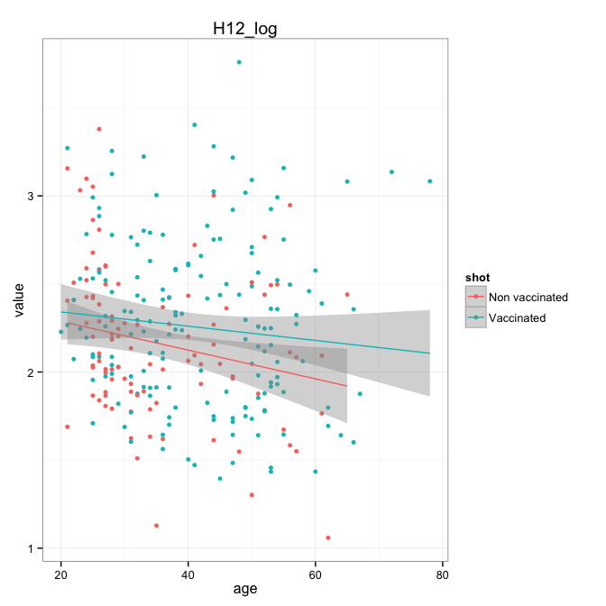

```
## [1] "Fit on the non vaccinated"
##
## Call:
## glm(formula = value ~ age, data = melted, subset = (shot == "Non vaccinated"))
##
## Deviance Residuals:
##     Min       1Q   Median       3Q      Max
## -1.8223  -0.3035  -0.0013   0.3128   1.1170
##
## Coefficients:
##             Estimate Std. Error t value Pr(>|t|)
## (Intercept)  0.19520    0.16433    1.19     0.24
## age          0.02253    0.00441    5.11  1.6e-06 ***
## ---
## Signif. codes:  0 '***' 0.001 '**' 0.01 '*' 0.05 '.' 0.1 ' ' 1
##
## (Dispersion parameter for gaussian family taken to be 0.2605)
##
##     Null deviance: 32.587  on 100  degrees of freedom
## Residual deviance: 25.787  on  99  degrees of freedom
##   (2 observations deleted due to missingness)
## AIC: 154.7
##
## Number of Fisher Scoring iterations: 2
##
## [1] "Fit on the vaccinated"
##
## Call:
## glm(formula = value ~ age, data = melted, subset = (shot == "Vaccinated"))
##
## Deviance Residuals:
##     Min       1Q   Median       3Q      Max
## -1.8675  -0.2746  -0.0132   0.3120   1.6909
##
## Coefficients:
##             Estimate Std. Error t value Pr(>|t|)
## (Intercept) -0.29617    0.14410   -2.06    0.041 *
## age          0.03608    0.00333   10.83   <2e-16 ***
## ---
## Signif. codes:  0 '***' 0.001 '**' 0.01 '*' 0.05 '.' 0.1 ' ' 1
##
## (Dispersion parameter for gaussian family taken to be 0.2731)
##
##     Null deviance: 77.081  on 166  degrees of freedom
## Residual deviance: 45.064  on 165  degrees of freedom
##   (1 observation deleted due to missingness)
## AIC: 261.2
##
## Number of Fisher Scoring iterations: 2
```

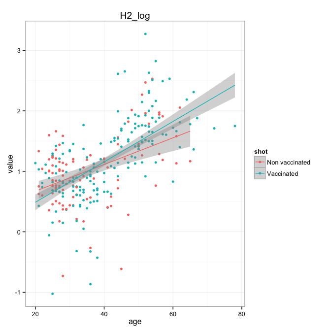

```
## [1] "Fit on the non vaccinated"
##
## Call:
## glm(formula = value ~ age, data = melted, subset = (shot == "Non vaccinated"))
##
## Deviance Residuals:
##     Min       1Q   Median       3Q      Max
## -1.0459  -0.3308  -0.0491   0.2972   1.3554
##
## Coefficients:
##             Estimate Std. Error t value Pr(>|t|)
## (Intercept)  3.76899    0.15390   24.49  < 2e-16 ***
## age         -0.01492    0.00415   -3.59  0.00051 ***
## ---
## Signif. codes:  0 '***' 0.001 '**' 0.01 '*' 0.05 '.' 0.1 ' ' 1
##
## (Dispersion parameter for gaussian family taken to be 0.234)
##
##     Null deviance: 26.660  on 102  degrees of freedom
## Residual deviance: 23.638  on 101  degrees of freedom
## AIC: 146.7
##
## Number of Fisher Scoring iterations: 2
##
## [1] "Fit on the vaccinated"
##
## Call:
## glm(formula = value ~ age, data = melted, subset = (shot == "Vaccinated"))
##
## Deviance Residuals:
##     Min       1Q   Median       3Q      Max
## -1.2203  -0.3096  -0.0271   0.3057   1.2901
##
## Coefficients:
##             Estimate Std. Error t value Pr(>|t|)
## (Intercept)  3.67397    0.13196   27.84   <2e-16 ***
## age         -0.00673    0.00305   -2.21    0.029 *
## ---
## Signif. codes:  0 '***' 0.001 '**' 0.01 '*' 0.05 '.' 0.1 ' ' 1
##
## (Dispersion parameter for gaussian family taken to be 0.2291)
##
##     Null deviance: 39.140  on 167  degrees of freedom
## Residual deviance: 38.024  on 166  degrees of freedom
## AIC: 233.2
##
## Number of Fisher Scoring iterations: 2
```

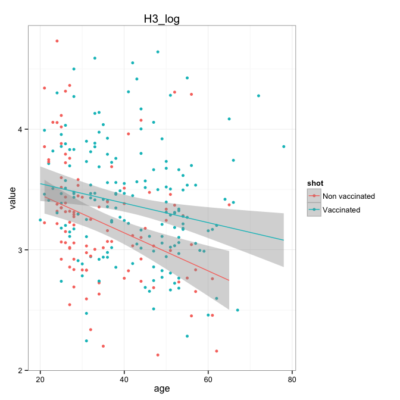

```
## [1] "Fit on the non vaccinated"
##
## Call:
## glm(formula = value ~ age, data = melted, subset = (shot == "Non vaccinated"))
##
## Deviance Residuals:
##     Min       1Q   Median       3Q      Max
## -1.8384  -0.3353   0.0242   0.3513   1.4259
##
## Coefficients:
##             Estimate Std. Error t value Pr(>|t|)
## (Intercept)  1.28820    0.20166    6.39  5.4e-09 ***
## age          0.00636    0.00543    1.17     0.24
## ---
## Signif. codes:  0 '***' 0.001 '**' 0.01 '*' 0.05 '.' 0.1 ' ' 1
##
## (Dispersion parameter for gaussian family taken to be 0.3986)
##
##     Null deviance: 40.409  on 101  degrees of freedom
## Residual deviance: 39.861  on 100  degrees of freedom
##   (1 observation deleted due to missingness)
## AIC: 199.6
##
## Number of Fisher Scoring iterations: 2
##
## [1] "Fit on the vaccinated"
##
## Call:
## glm(formula = value ~ age, data = melted, subset = (shot == "Vaccinated"))
##
## Deviance Residuals:
##     Min       1Q   Median       3Q      Max
## -2.4651  -0.2953   0.0636   0.2884   2.4023
##
## Coefficients:
##             Estimate Std. Error t value Pr(>|t|)
## (Intercept)  1.59274    0.19216    8.29  4.3e-14 ***
## age          0.00139    0.00443    0.31     0.75
## ---
## Signif. codes:  0 '***' 0.001 '**' 0.01 '*' 0.05 '.' 0.1 ' ' 1
##
## (Dispersion parameter for gaussian family taken to be 0.4736)
##
##     Null deviance: 76.291  on 162  degrees of freedom
## Residual deviance: 76.244  on 161  degrees of freedom
##   (5 observations deleted due to missingness)
## AIC: 344.7
##
## Number of Fisher Scoring iterations: 2
```

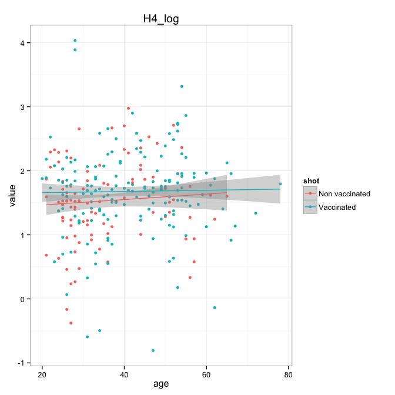

```
## [1] "Fit on the non vaccinated"
##
## Call:
## glm(formula = value ~ age, data = melted, subset = (shot == "Non vaccinated"))
##
## Deviance Residuals:
##     Min       1Q   Median       3Q      Max
## -1.2255  -0.2625  -0.0052   0.2430   1.1616
##
## Coefficients:
##             Estimate Std. Error t value Pr(>|t|)
## (Intercept)  1.07372    0.14351    7.48  2.8e-11 ***
## age          0.00921    0.00387    2.38    0.019 *
## ---
## Signif. codes:  0 '***' 0.001 '**' 0.01 '*' 0.05 '.' 0.1 ' ' 1
##
## (Dispersion parameter for gaussian family taken to be 0.2035)
##
##     Null deviance: 21.707  on 102  degrees of freedom
## Residual deviance: 20.555  on 101  degrees of freedom
## AIC: 132.3
##
## Number of Fisher Scoring iterations: 2
##
## [1] "Fit on the vaccinated"
##
## Call:
## glm(formula = value ~ age, data = melted, subset = (shot == "Vaccinated"))
##
## Deviance Residuals:
##     Min       1Q   Median       3Q      Max
## -1.2335  -0.3673  -0.0327   0.2890   1.3736
##
## Coefficients:
##             Estimate Std. Error t value Pr(>|t|)
## (Intercept)  1.11220    0.13742    8.09  1.2e-13 ***
## age          0.01539    0.00318    4.85  2.9e-06 ***
## ---
## Signif. codes:  0 '***' 0.001 '**' 0.01 '*' 0.05 '.' 0.1 ' ' 1
##
## (Dispersion parameter for gaussian family taken to be 0.2484)
##
##     Null deviance: 47.068  on 167  degrees of freedom
## Residual deviance: 41.236  on 166  degrees of freedom
## AIC: 246.8
##
## Number of Fisher Scoring iterations: 2
```

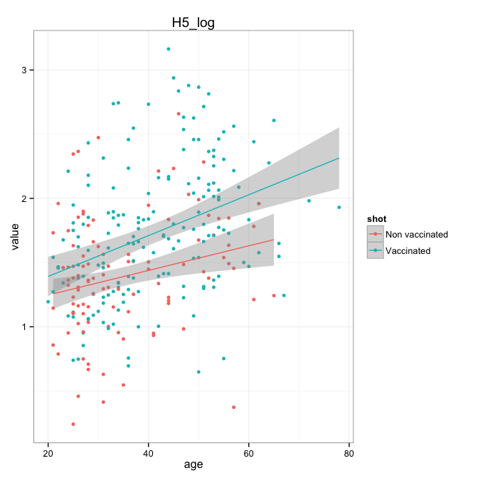

```
## [1] "Fit on the non vaccinated"
##
## Call:
## glm(formula = value ~ age, data = melted, subset = (shot == "Non vaccinated"))
##
## Deviance Residuals:
##     Min       1Q   Median       3Q      Max
## -1.1667  -0.1689   0.0435   0.2046   0.5875
##
## Coefficients:
##             Estimate Std. Error t value Pr(>|t|)
## (Intercept)  1.26761    0.09872   12.84   <2e-16 ***
## age          0.00148    0.00266    0.55     0.58
## ---
## Signif. codes:  0 '***' 0.001 '**' 0.01 '*' 0.05 '.' 0.1 ' ' 1
##
## (Dispersion parameter for gaussian family taken to be 0.0963)
##
##     Null deviance: 9.7556  on 102  degrees of freedom
## Residual deviance: 9.7260  on 101  degrees of freedom
## AIC: 55.23
##
## Number of Fisher Scoring iterations: 2
##
## [1] "Fit on the vaccinated"
##
## Call:
## glm(formula = value ~ age, data = melted, subset = (shot == "Vaccinated"))
##
## Deviance Residuals:
##     Min       1Q   Median       3Q      Max
## -0.7271  -0.1516  -0.0027   0.1635   0.5679
##
## Coefficients:
##             Estimate Std. Error t value Pr(>|t|)
## (Intercept)  1.20868    0.06892   17.54   <2e-16 ***
## age          0.00097    0.00159    0.61     0.54
## ---
## Signif. codes:  0 '***' 0.001 '**' 0.01 '*' 0.05 '.' 0.1 ' ' 1
##
## (Dispersion parameter for gaussian family taken to be 0.06248)
##
##     Null deviance: 10.394  on 167  degrees of freedom
## Residual deviance: 10.371  on 166  degrees of freedom
## AIC: 14.89
##
## Number of Fisher Scoring iterations: 2
```

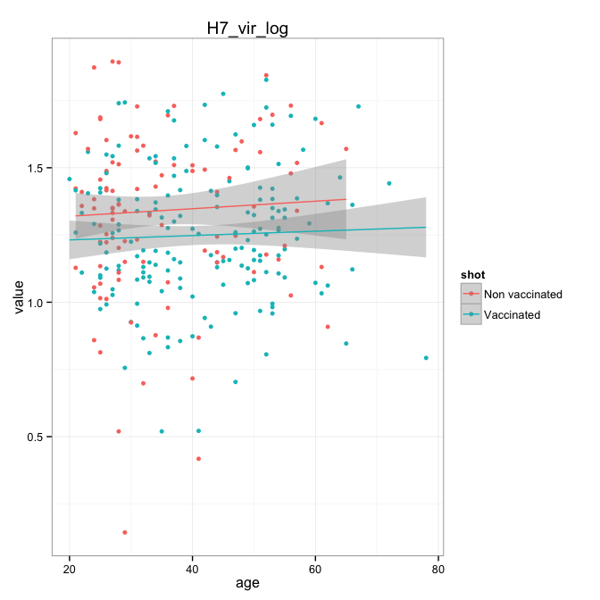

```
## [1] "Fit on the non vaccinated"
##
## Call:
## glm(formula = value ~ age, data = melted, subset = (shot == "Non vaccinated"))
##
## Deviance Residuals:
##     Min       1Q   Median       3Q      Max
## -1.5138  -0.1574   0.0159   0.1793   0.7812
##
## Coefficients:
##             Estimate Std. Error t value Pr(>|t|)
## (Intercept)  1.78291    0.09564   18.64   <2e-16 ***
## age         -0.00379    0.00258   -1.47     0.14
## ---
## Signif. codes:  0 '***' 0.001 '**' 0.01 '*' 0.05 '.' 0.1 ' ' 1
##
## (Dispersion parameter for gaussian family taken to be 0.09039)
##
##     Null deviance: 9.3248  on 102  degrees of freedom
## Residual deviance: 9.1296  on 101  degrees of freedom
## AIC: 48.71
##
## Number of Fisher Scoring iterations: 2
##
## [1] "Fit on the vaccinated"
##
## Call:
## glm(formula = value ~ age, data = melted, subset = (shot == "Vaccinated"))
##
## Deviance Residuals:
##     Min       1Q   Median       3Q      Max
## -0.8782  -0.1996  -0.0136   0.1835   1.0110
##
## Coefficients:
##             Estimate Std. Error t value Pr(>|t|)
## (Intercept)  1.77300    0.07371   24.05   <2e-16 ***
## age         -0.00347    0.00170   -2.04    0.043 *
## ---
## Signif. codes:  0 '***' 0.001 '**' 0.01 '*' 0.05 '.' 0.1 ' ' 1
##
## (Dispersion parameter for gaussian family taken to be 0.07147)
##
##     Null deviance: 12.161  on 167  degrees of freedom
## Residual deviance: 11.864  on 166  degrees of freedom
## AIC: 37.48
##
## Number of Fisher Scoring iterations: 2
```

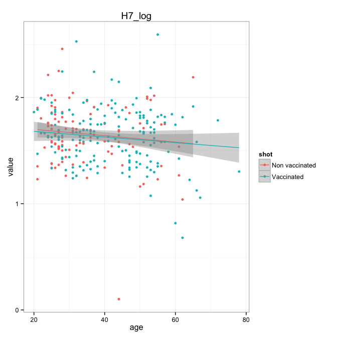